# Classifying Driver Behavior

Ryan Yee

2023-12-14

## Dataset Description

The dataset at hand focuses on predicting driving behavior, specifically targeting aggressive driving actions that contribute significantly to road traffic accidents. The data was collected using an Android application designed to utilize the accelerometer and gyroscope sensors on smartphones, with a specific emphasis on a Samsung Galaxy S21 device. The recorded information includes acceleration and rotation data along the X, Y, and Z axes, timestamp information, and classification labels indicating whether the driving behavior is categorized as Slow, Normal, or Aggressive. Noteworthy aspects of the dataset include a sampling rate of 2 samples per second, removal of gravitational acceleration, and the use of sensors for data collection.

## Introduction to the Machine Learning Project

In this machine learning project, our primary goal is to develop a model capable of swiftly and accurately predicting dangerous driving behavior. Aggressive driving actions, such as speeding, abrupt braking, and sudden turns, are crucial factors in numerous fatal crashes, constituting over half of reported incidents. Our focus lies in enhancing road safety by anticipating and classifying driving behaviors. The dataset, derived from sensor data of a Samsung Galaxy S21, enables us to employ deep learning and machine learning techniques for efficient prediction.

## Inspiration and Motive

Imagine a world where road users are informed in real-time about potentially dangerous driving behaviors, allowing them to adjust and respond proactively. Inspired by the desire to mitigate road accidents and ensure the safety of individuals, this project aims to provide a technological solution. The prediction of aggressive driving behaviors seeks to contribute to a safer and more secure road environment. The motivation stems from the belief that technology can play a pivotal role in preventing accidents and safeguarding lives.

## Additional Information

Understanding the motivation behind predicting aggressive driving behavior is crucial. Forecasting dangerous driving actions facilitates informed decision-making on the road. This model aims to be a proactive tool, not only for individual drivers but also for broader applications in enhancing road safety measures.

Our model incorporates data-driven insights into the realm of driving behavior. The relevance of this model lies in its potential to empower drivers, passengers, and even automated systems with the ability to anticipate and respond to aggressive driving actions, ultimately contributing to a safer and more secure road ecosystem.

## Project Roadmap

In embarking on the development of our machine learning model to predict aggressive driving behavior, we will begin by collecting and preprocessing data through an Android application specifically designed for this purpose on the Samsung Galaxy S21. The dataset, derived from accelerometer and gyroscope sensors, will undergo thorough cleaning and gravitational acceleration removal to ensure data integrity. Subsequently, an in-depth Exploratory Data Analysis (EDA) will be conducted, visually inspecting acceleration and rotation patterns for each driving behavior category—Slow, Normal, and Aggressive. Feature engineering will follow, extracting pertinent features and encoding categorical labels for predictive modeling.

## Exploratory Data Analysis

Before delving into the modeling phase, a critical step is to conduct an in-depth exploration of our dataset. The raw data, collected through smartphone sensors capturing accelerometer and gyroscope information, may require careful examination and preparation before its application in predictive modeling. Initial data loading may reveal imperfections such as variables needing conversion to factors or missing values requiring attention.

Our primary objective is to create a response variable that distinctly categorizes whether a driving scenario is classified as Slow, Normal, or Aggressive. This involves meticulous data manipulation and cleaning to ensure the dataset’s readiness for subsequent analysis. Variables may need to be transformed or encoded, and missing values addressed before moving forward.

In this exploratory data analysis (EDA) section, we will systematically navigate through data manipulation and tidying processes, setting the stage for a comprehensive understanding of the dataset. Visualizations and analytical functions will be employed to scrutinize key variables, unveiling patterns, distributions, and potential correlations. This critical phase is pivotal in laying the groundwork for robust predictive modeling, ensuring that our data is not only pristine but also conducive to extracting meaningful insights for the task of predicting driving behavior accurately.

### Loading and Exploring Raw Data

Lets load the motion data collected by the accelerometer and gyroscope sensors! The sourced data-set was already split into train/testing sets. However, we will combine them and conduct a custom split.

```r
# Read the datasets
train <- read.csv('~/Github/pstat131FinalProject/data/train_motion_data.csv')
test <- read.csv('~/Github/pstat131FinalProject/data/test_motion_data.csv')

# Combine the datasets
combined_data <- rbind(train, test)

# Check the dimensions of the combined dataset
dim(combined_data)
```

```
## [1] 6728    8
```

```r
# Export the combined dataset to a new CSV file
#write.csv(combined_data, '~/Github/pstat131FinalProject/data/combined_motion_data.csv', row.names = FALSE)
```

Our data set contains 6728 rows and 8 columns.

Now lets take a look at the variables:

```r
head(combined_data)
```

```
##      AccX    AccY     AccZ    GyroX     GyroY   GyroZ  Class Timestamp
## 1  0.0000  0.0000  0.00000  0.05941 -0.174707 0.10194 NORMAL   3581629
## 2 -1.6249 -1.0825 -0.20418 -0.02856  0.051313 0.13554 NORMAL   3581630
## 3 -0.5947 -0.1224  0.22050 -0.01939 -0.029322 0.08789 NORMAL   3581630
## 4  0.7385 -0.2285  0.66773  0.06979 -0.029932 0.05490 NORMAL   3581631
## 5  0.1017  0.7776 -0.06673  0.03070 -0.003665 0.05490 NORMAL   3581631
## 6  0.1585  0.3459  0.35527  0.02153  0.115454 0.01458 NORMAL   3581632
```

### Variable Description

Our data set consists of the following variables:

- **AccX**: A numerical variable representing acceleration along the X-axis in meters per second squared (m/s²).
- **AccY**: A numerical variable representing acceleration along the Y-axis in meters per second squared (m/s²).
- **AccZ**: A numerical variable representing acceleration along the Z-axis in meters per second squared (m/s²).
- **GyroX**: A numerical variable representing rotation along the X-axis in degrees per second (°/s).
- **GyroY**: A numerical variable representing rotation along the Y-axis in degrees per second (°/s).
- **GyroZ**: A numerical variable representing rotation along the Z-axis in degrees per second (°/s).
- **Class**: A categorical variable (factor) indicating the driving behavior classification, which includes categories such as SLOW, NORMAL, and AGGRESSIVE.
- **Timestamp**: An integer variable representing time in seconds.

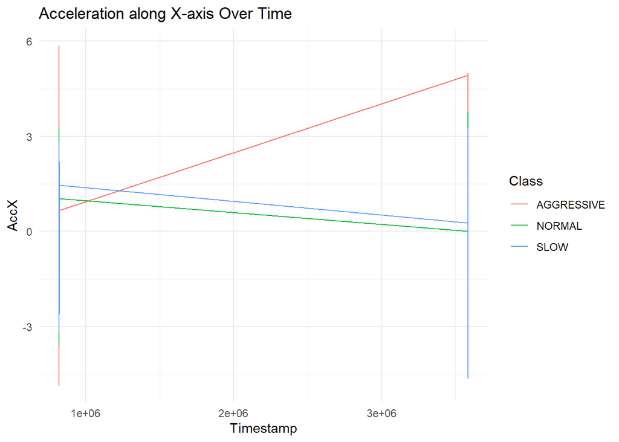

```r
# Visualization of Accelerometer readings
ggplot(combined_data, aes(x = Timestamp, y = AccX, color = Class)) +
  geom_line() +
  labs(title = "Acceleration along X-axis Over Time", x = "Timestamp", y = "AccX") +
  theme_minimal()
```

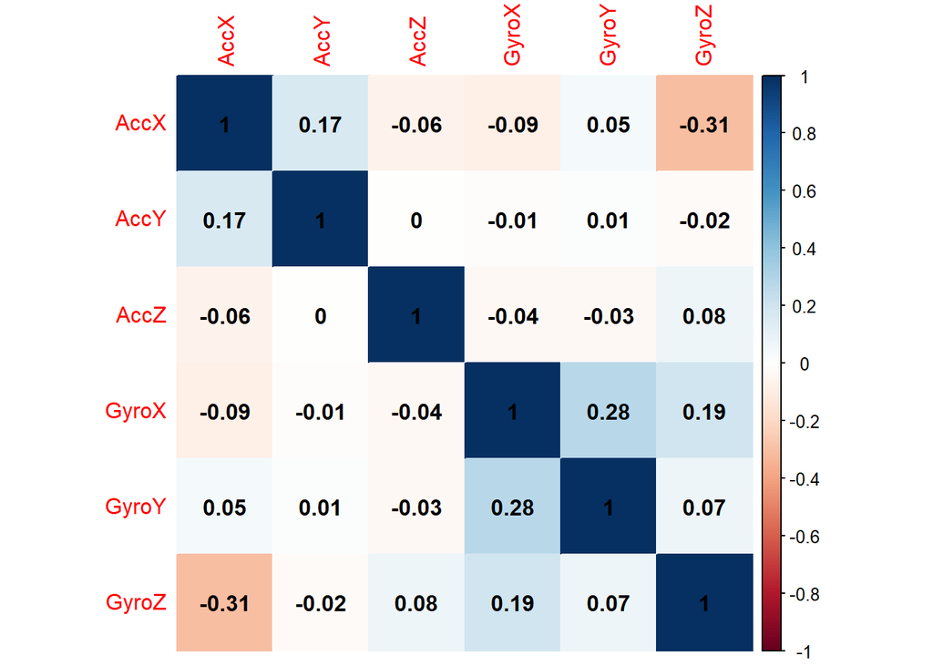

```r
# Correlation matrix for numerical variables
cor_matrix <- cor(combined_data[, c("AccX", "AccY", "AccZ", "GyroX", "GyroY", "GyroZ")])
corrplot(cor_matrix, method = "color", addCoef.col = "black")
```

There seems to be a minimal negative correlation between the variables GyroZ and AccX, this is because there will be significant increase in down-force when accelerating. For example, when launching the car, the front of the car will be lowered, and the rear will be lifted.

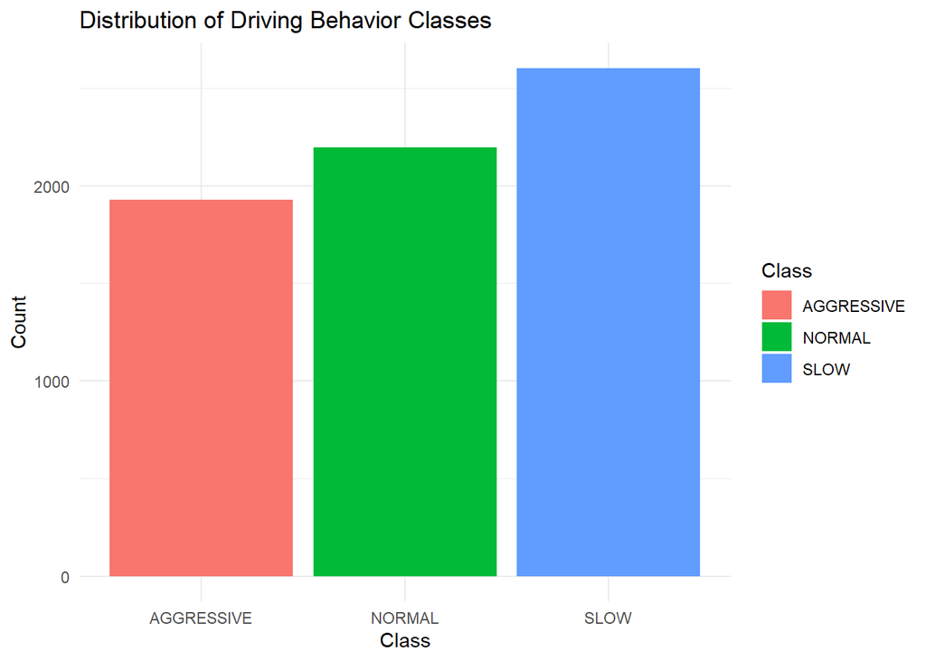

```r
# Plot the distribution of the 'Class' variable
ggplot(combined_data, aes(x = Class, fill = Class)) +
  geom_bar() +
  labs(title = "Distribution of Driving Behavior Classes", x = "Class", y = "Count") +
  theme_minimal()
```

We can see that the distribution of the Driving Behavior Class are relatively balanced hence no up-sampling will be needed.

It is possible for the sensors to mal-function so let’s check for missing data in our data set just in case!

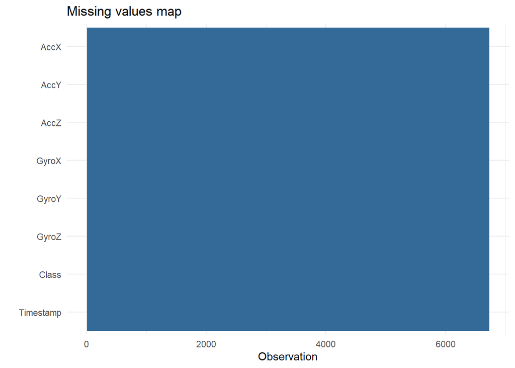

```r
combined_data %>% missing_plot()
```

Good! It seems like We do not have any missing data! Let’s proceed!

Since we want to classify the driving behavior of the driver, our response variable will be `Class`, which we will need to convert to a factor. The `Class` variable contains three different Categories: SLOW, NORMAL, and AGGRESSIVE; which is a multiclass variable. We can also aggregate the SLOW and NORMAL class into a single class, SAFE, to implement a binary classification. We will proceed with a multiclass classification for now, and explore binary classification later.

```r
combined_data <- combined_data %>%
  mutate(
    Class = as.factor(Class)
  )

head(combined_data)
```

```
##      AccX    AccY     AccZ    GyroX     GyroY   GyroZ  Class Timestamp
## 1  0.0000  0.0000  0.00000  0.05941 -0.174707 0.10194 NORMAL   3581629
## 2 -1.6249 -1.0825 -0.20418 -0.02856  0.051313 0.13554 NORMAL   3581630
## 3 -0.5947 -0.1224  0.22050 -0.01939 -0.029322 0.08789 NORMAL   3581630
## 4  0.7385 -0.2285  0.66773  0.06979 -0.029932 0.05490 NORMAL   3581631
## 5  0.1017  0.7776 -0.06673  0.03070 -0.003665 0.05490 NORMAL   3581631
## 6  0.1585  0.3459  0.35527  0.02153  0.115454 0.01458 NORMAL   3581632
```

Perform an initial split of the data. Stratify by the outcome variable.

```r
# Set a seed for reproducibility
set.seed(123)

# Define the percentage for the training set (e.g., 80%)
train_percent <- 0.8

# Create a data splitting object with stratified sampling
data_split <- initial_split(combined_data, prop = train_percent, strata = Class)

# Extract the training and testing sets
data_train <- training(data_split)
data_test <- testing(data_split)

# Check the dimensions of the training and testing sets
dim(data_train)
```

```
## [1] 5381    8
```

```r
dim(data_test)
```

```
## [1] 1347    8
```

```r
# Set seed for reproducibility
set.seed(123)

# Define the number of folds
num_folds <- 5

# Create a cross-validation object
data_folds <- vfold_cv(data_train, v = num_folds, strata = "Class")
```

Stratified sampling for cross-validation is useful because it ensures that each subgroup or class in the dataset is adequately represented in both the training and validation sets. This enhances the reliability of the model evaluation process and contributes to better generalization performance.

Set up a recipe to predict `Class` with `AccX`, `AccY`, `AccZ`, `GyroX`, `GyroY`, `GyroZ`.

- Center and scale all predictors.

We will not be including `Timestamp` as a predictor as it will lead to over-fitting. This is because the classes are ordered by `Timestamp` by the nature of the data collection process. Rows with similar `Timestamp` are very likely to have the same class. Hence the `Timestamp` variable should be omitted.

```r
# Create a recipe
data_recipe <- recipe(Class ~ AccX + AccY + AccZ + GyroX + GyroY + GyroZ, data = data_train) %>%

  # Center and scale all predictors
  step_normalize(all_predictors())
```

```r
summary(data_recipe)
```

```
## # A tibble: 7 × 4
##   variable type      role      source
##   <chr>    <list>    <chr>     <chr>
## 1 AccX     <chr [2]> predictor original
## 2 AccY     <chr [2]> predictor original
## 3 AccZ     <chr [2]> predictor original
## 4 GyroX    <chr [2]> predictor original
## 5 GyroY    <chr [2]> predictor original
## 6 GyroZ    <chr [2]> predictor original
## 7 Class    <chr [3]> outcome   original
```

```r
library(discrim)
# Specify linear discriminant analysis (LDA) model
lda_model <- discrim_linear(engine = "MASS")

# Create a workflow
lda_workflow <- workflow() %>%
  add_recipe(data_recipe) %>%
  add_model(lda_model)

# Fit the model to the training data
data_fit_lda <- fit(lda_workflow, data = data_train)
```

```r
# Specify quadratic discriminant analysis (QDA) model
qda_model <- discrim_quad(engine = "MASS")

# Create a workflow
qda_workflow <- workflow() %>%
  add_recipe(data_recipe) %>%
  add_model(qda_model)

# Fit the model to the training data
data_fit_qda <- fit(qda_workflow, data = data_train)
```

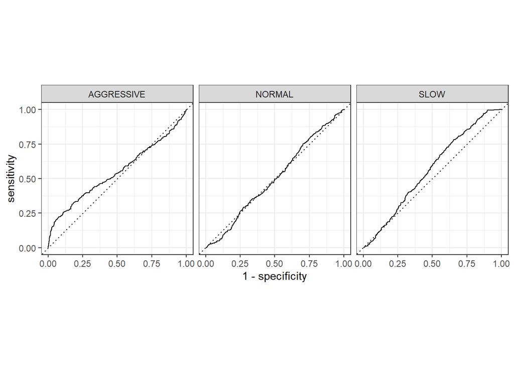

```r
# Load required libraries
library(tidymodels)
library(yardstick)

# Make predictions using each model on the training data
#predictions_log <- predict(titanic_fit_log, new_data = train_data)
predictions_lda <- predict(data_fit_lda, new_data = data_train)
predictions_qda <- predict(data_fit_qda, new_data = data_train)
#predictions_knn <- predict(titanic_fit_knn, new_data = train_data)

# Combine predictions for all models with true labels
all_predictions <- bind_cols(
  truth = data_train$Class,

  lda = as.numeric(predictions_lda$.pred_class),#Convert to numeric
  qda = as.numeric(predictions_qda$.pred_class)#Convert to numeric
)


final_lda_model_test <- augment(data_fit_lda,
                               data_test) %>%
  select(Class, starts_with(".pred"))

roc_results_lda <- roc_auc(final_lda_model_test, truth = Class, .pred_AGGRESSIVE:.pred_SLOW)


roc_curve(final_lda_model_test, truth = Class, .pred_AGGRESSIVE:.pred_SLOW) %>%
  autoplot()
```

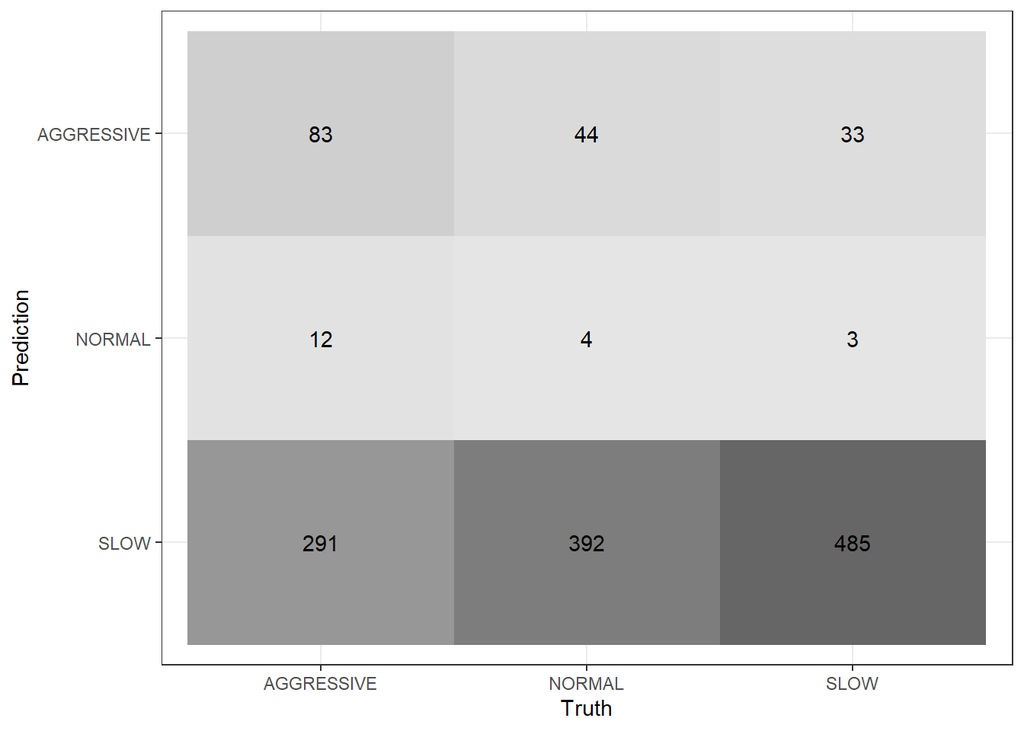

```r
conf_mat(final_lda_model_test, truth = Class,
         .pred_class) %>%
  autoplot(type = "heatmap")
```

```r
roc_results_lda
```

```
## # A tibble: 1 × 3
##   .metric .estimator .estimate
##   <chr>   <chr>          <dbl>
## 1 roc_auc hand_till      0.538
```

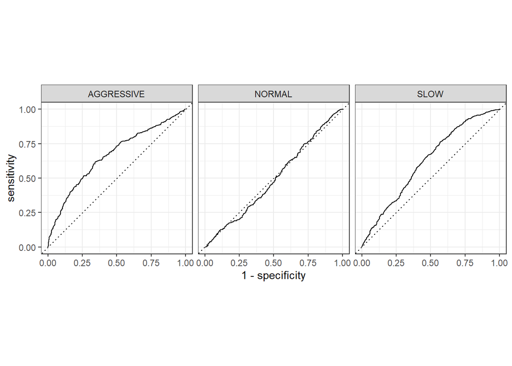

```r
final_qda_model_test <- augment(data_fit_qda,
                               data_test) %>%
  select(Class, starts_with(".pred"))

roc_results_qda <- roc_auc(final_qda_model_test, truth = Class, .pred_AGGRESSIVE:.pred_SLOW)


roc_curve(final_qda_model_test, truth = Class, .pred_AGGRESSIVE:.pred_SLOW) %>%
  autoplot()
```

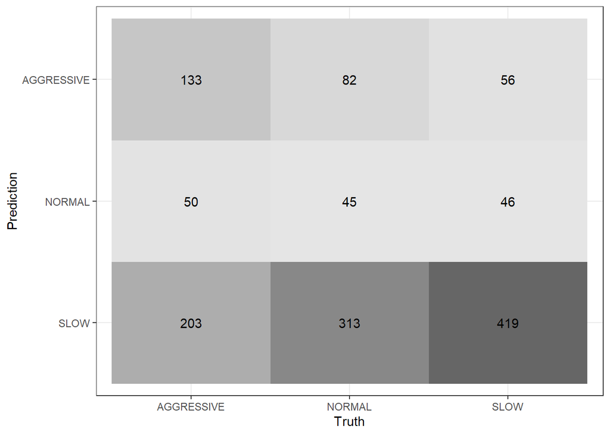

```r
conf_mat(final_qda_model_test, truth = Class,
         .pred_class) %>%
  autoplot(type = "heatmap")
```

```r
roc_results_qda
```

```
## # A tibble: 1 × 3
##   .metric .estimator .estimate
##   <chr>   <chr>          <dbl>
## 1 roc_auc hand_till      0.594
```

```r
# Create a KNN model with k = 5 using the kknn engine
knn_model <- nearest_neighbor(neighbors = tune()) %>%
  set_mode("classification") %>%
  set_engine("kknn")

knn_data_workflow <- workflow() %>%
  add_recipe(data_recipe) %>%
  add_model(knn_model)

neighbors_grid <- grid_regular(neighbors(range = c(1, 10)), levels = 10)
```

```r
knn_tune_res_data <- tune_grid(
  object = knn_data_workflow,
  resamples = data_folds,
  grid = neighbors_grid
)
```

```r
collect_metrics(knn_tune_res_data)
```

```
## # A tibble: 20 × 7
##    neighbors .metric  .estimator  mean     n std_err .config
##        <int> <chr>    <chr>      <dbl> <int>   <dbl> <chr>
##  1         1 accuracy multiclass 0.361     5 0.00605 Preprocessor1_Model01
##  2         1 roc_auc  hand_till  0.517     5 0.00435 Preprocessor1_Model01
##  3         2 accuracy multiclass 0.361     5 0.00605 Preprocessor1_Model02
##  4         2 roc_auc  hand_till  0.529     5 0.00499 Preprocessor1_Model02
##  5         3 accuracy multiclass 0.361     5 0.00605 Preprocessor1_Model03
##  6         3 roc_auc  hand_till  0.535     5 0.00481 Preprocessor1_Model03
##  7         4 accuracy multiclass 0.361     5 0.00605 Preprocessor1_Model04
##  8         4 roc_auc  hand_till  0.538     5 0.00478 Preprocessor1_Model04
##  9         5 accuracy multiclass 0.369     5 0.00577 Preprocessor1_Model05
## 10         5 roc_auc  hand_till  0.541     5 0.00471 Preprocessor1_Model05
## 11         6 accuracy multiclass 0.375     5 0.00499 Preprocessor1_Model06
## 12         6 roc_auc  hand_till  0.544     5 0.00468 Preprocessor1_Model06
## 13         7 accuracy multiclass 0.379     5 0.00419 Preprocessor1_Model07
## 14         7 roc_auc  hand_till  0.546     5 0.00477 Preprocessor1_Model07
## 15         8 accuracy multiclass 0.381     5 0.00455 Preprocessor1_Model08
## 16         8 roc_auc  hand_till  0.548     5 0.00496 Preprocessor1_Model08
## 17         9 accuracy multiclass 0.384     5 0.00493 Preprocessor1_Model09
## 18         9 roc_auc  hand_till  0.550     5 0.00495 Preprocessor1_Model09
## 19        10 accuracy multiclass 0.387     5 0.00623 Preprocessor1_Model10
## 20        10 roc_auc  hand_till  0.552     5 0.00495 Preprocessor1_Model10
```

```r
best_knn_data <- select_by_one_std_err(knn_tune_res_data,
                          metric = "roc_auc",
                          neighbors
                          )
best_knn_data
```

```
## # A tibble: 1 × 9
##   neighbors .metric .estimator  mean     n std_err .config          .best .bound
##       <int> <chr>   <chr>      <dbl> <int>   <dbl> <chr>            <dbl>  <dbl>
## 1         8 roc_auc hand_till  0.548     5 0.00496 Preprocessor1_M… 0.552  0.547
```

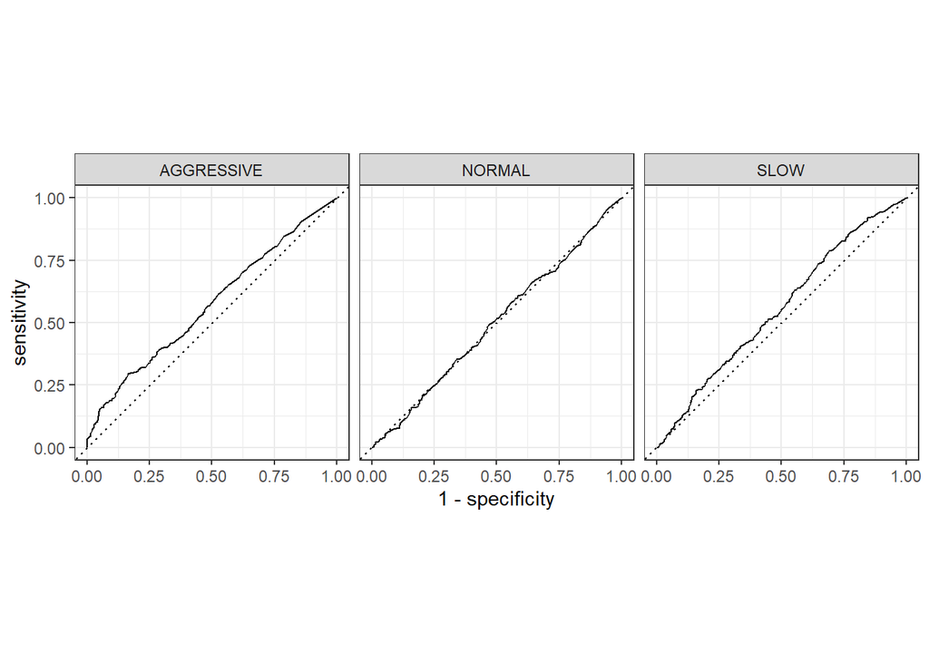

```r
# Logistic Regression

knn_final_data <- finalize_workflow(knn_data_workflow,
                                      best_knn_data)

knn_final_data <- fit(knn_final_data,
                        data = data_train)


final_knn_model_test <- augment(knn_final_data,
                               data_test) %>%
  select(Class, starts_with(".pred"))

roc_results_knn <- roc_auc(final_knn_model_test, truth = Class, .pred_AGGRESSIVE:.pred_SLOW)


roc_curve(final_knn_model_test, truth = Class, .pred_AGGRESSIVE:.pred_SLOW) %>%
  autoplot()
```

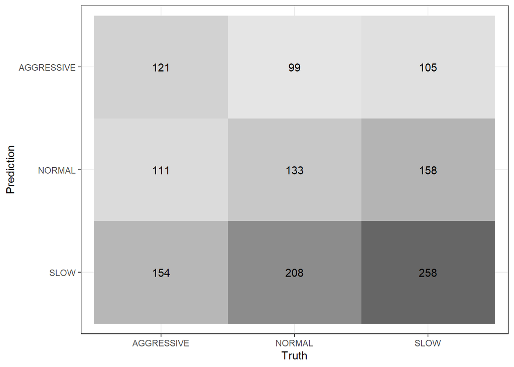

```r
conf_mat(final_knn_model_test, truth = Class,
         .pred_class) %>%
  autoplot(type = "heatmap")
```

```r
roc_results_knn
```

```
## # A tibble: 1 × 3
##   .metric .estimator .estimate
##   <chr>   <chr>          <dbl>
## 1 roc_auc hand_till      0.542
```

```r
en_spec <- multinom_reg(mixture = tune(),
                        penalty = tune()) %>%
  set_mode("classification") %>%
  set_engine("glmnet")

en_workflow <- workflow() %>%
  add_recipe(data_recipe) %>%
  add_model(en_spec)

en_grid <- grid_regular(penalty(range = c(0.01, 3), trans = identity_trans()),
                        mixture(range = c(0, 1)),
                             levels = 10)
```

```r
rf_class_spec <- rand_forest(mtry = tune(),
                           trees = tune(),
                           min_n = tune()) %>%
  set_engine("ranger", importance = "impurity") %>%
  set_mode("classification")

rf_class_wf <- workflow() %>%
  add_model(rf_class_spec) %>%
  add_recipe(data_recipe)
```

```r
rf_grid <- grid_regular(mtry(range = c(1, 8)),
                        trees(range = c(200, 600)),
                        min_n(range = c(10, 20)),
                        levels = 8)
rf_grid
```

```
## # A tibble: 512 × 3
##     mtry trees min_n
##    <int> <int> <int>
##  1     1   200    10
##  2     2   200    10
##  3     3   200    10
##  4     4   200    10
##  5     5   200    10
##  6     6   200    10
##  7     7   200    10
##  8     8   200    10
##  9     1   257    10
## 10     2   257    10
## # ℹ 502 more rows
```

```r
# # Tune Elastic Net Model
# en_tune_res <- tune_grid(
#   en_workflow,
#   resamples = data_folds,
#   grid = en_grid
# )
```

```r
# # Tune Random Forest Model
# tune_class <- tune_grid(
#   rf_class_wf,
#   resamples = data_folds,
#   grid = rf_grid
# )
```

```r
# save(en_tune_res, file = "en_tune_res.rda")
# save(tune_class, file = "tune_class.rda")
```

```r
load("en_tune_res.rda")
load("tune_class.rda")
```

```r
collect_metrics(en_tune_res)
```

```
## # A tibble: 200 × 8
##    penalty mixture .metric  .estimator  mean     n  std_err .config
##      <dbl>   <dbl> <chr>    <chr>      <dbl> <int>    <dbl> <chr>
##  1   0.01        0 accuracy multiclass 0.424     5 0.00356  Preprocessor1_Model…
##  2   0.01        0 roc_auc  hand_till  0.544     5 0.00846  Preprocessor1_Model…
##  3   0.342       0 accuracy multiclass 0.400     5 0.00182  Preprocessor1_Model…
##  4   0.342       0 roc_auc  hand_till  0.542     5 0.00909  Preprocessor1_Model…
##  5   0.674       0 accuracy multiclass 0.389     5 0.000624 Preprocessor1_Model…
##  6   0.674       0 roc_auc  hand_till  0.541     5 0.00920  Preprocessor1_Model…
##  7   1.01        0 accuracy multiclass 0.388     5 0.000358 Preprocessor1_Model…
##  8   1.01        0 roc_auc  hand_till  0.541     5 0.00931  Preprocessor1_Model…
##  9   1.34        0 accuracy multiclass 0.388     5 0.000228 Preprocessor1_Model…
## 10   1.34        0 roc_auc  hand_till  0.540     5 0.00933  Preprocessor1_Model…
## # ℹ 190 more rows
```

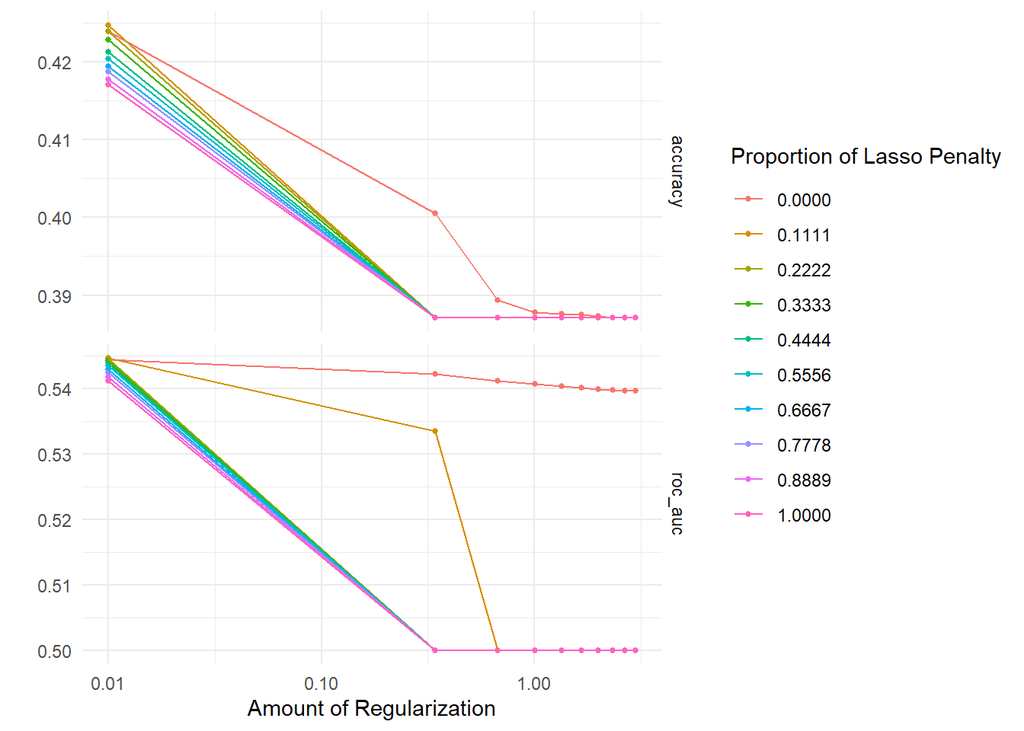

```r
autoplot(en_tune_res) + theme_minimal()
```

```r
collect_metrics(tune_class)
```

```
## # A tibble: 1,024 × 9
##     mtry trees min_n .metric  .estimator  mean     n std_err .config
##    <int> <int> <int> <chr>    <chr>      <dbl> <int>   <dbl> <chr>
##  1     1   200    10 accuracy multiclass 0.419     5 0.00603 Preprocessor1_Mode…
##  2     1   200    10 roc_auc  hand_till  0.586     5 0.00586 Preprocessor1_Mode…
##  3     2   200    10 accuracy multiclass 0.413     5 0.00472 Preprocessor1_Mode…
##  4     2   200    10 roc_auc  hand_till  0.583     5 0.00626 Preprocessor1_Mode…
##  5     3   200    10 accuracy multiclass 0.420     5 0.00839 Preprocessor1_Mode…
##  6     3   200    10 roc_auc  hand_till  0.580     5 0.00701 Preprocessor1_Mode…
##  7     4   200    10 accuracy multiclass 0.410     5 0.00784 Preprocessor1_Mode…
##  8     4   200    10 roc_auc  hand_till  0.584     5 0.00488 Preprocessor1_Mode…
##  9     5   200    10 accuracy multiclass 0.413     5 0.00667 Preprocessor1_Mode…
## 10     5   200    10 roc_auc  hand_till  0.581     5 0.00688 Preprocessor1_Mode…
## # ℹ 1,014 more rows
```

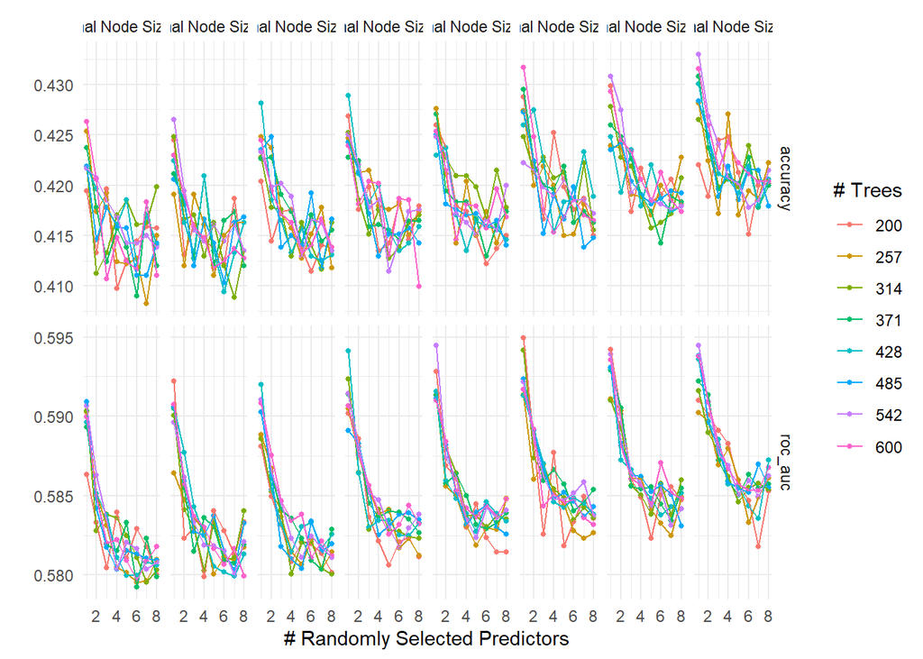

```r
autoplot(tune_class) + theme_minimal()
```

```r
show_best(en_tune_res, n = 1)
```

```
## # A tibble: 1 × 8
##   penalty mixture .metric .estimator  mean     n std_err .config
##     <dbl>   <dbl> <chr>   <chr>      <dbl> <int>   <dbl> <chr>
## 1    0.01   0.111 roc_auc hand_till  0.545     5 0.00850 Preprocessor1_Model011
```

```r
best_en <- select_best(en_tune_res)
```

```r
show_best(tune_class, n = 1)
```

```
## # A tibble: 1 × 9
##    mtry trees min_n .metric .estimator  mean     n std_err .config
##   <int> <int> <int> <chr>   <chr>      <dbl> <int>   <dbl> <chr>
## 1     1   200    17 roc_auc hand_till  0.595     5 0.00658 Preprocessor1_Model3…
```

```r
best_rf_class <- select_best(tune_class)
```

```r
final_rf_model <- finalize_workflow(rf_class_wf, best_rf_class)
final_rf_model <- fit(final_rf_model, data_train)
```

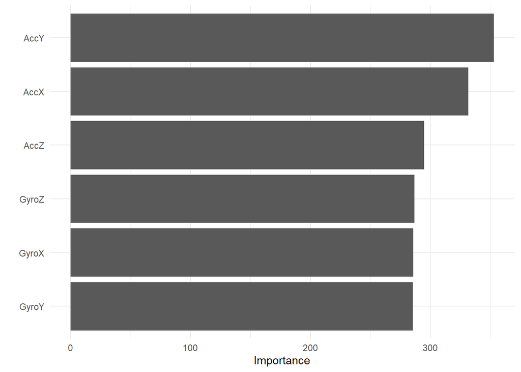

```r
final_rf_model %>% extract_fit_parsnip() %>%
  vip() +
  theme_minimal()
```

```r
final_rf_model_test <- augment(final_rf_model,
                               data_test) %>%
  select(Class, starts_with(".pred"))

roc_auc(final_rf_model_test, truth = Class, .pred_AGGRESSIVE:.pred_SLOW)
```

```
## # A tibble: 1 × 3
##   .metric .estimator .estimate
##   <chr>   <chr>          <dbl>
## 1 roc_auc hand_till      0.586
```

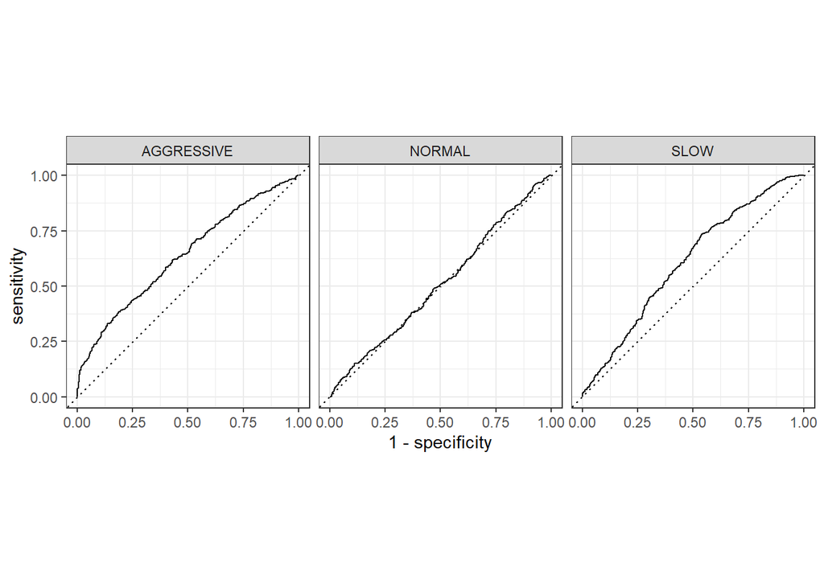

```r
roc_curve(final_rf_model_test, truth = Class, .pred_AGGRESSIVE:.pred_SLOW) %>%
  autoplot()
```

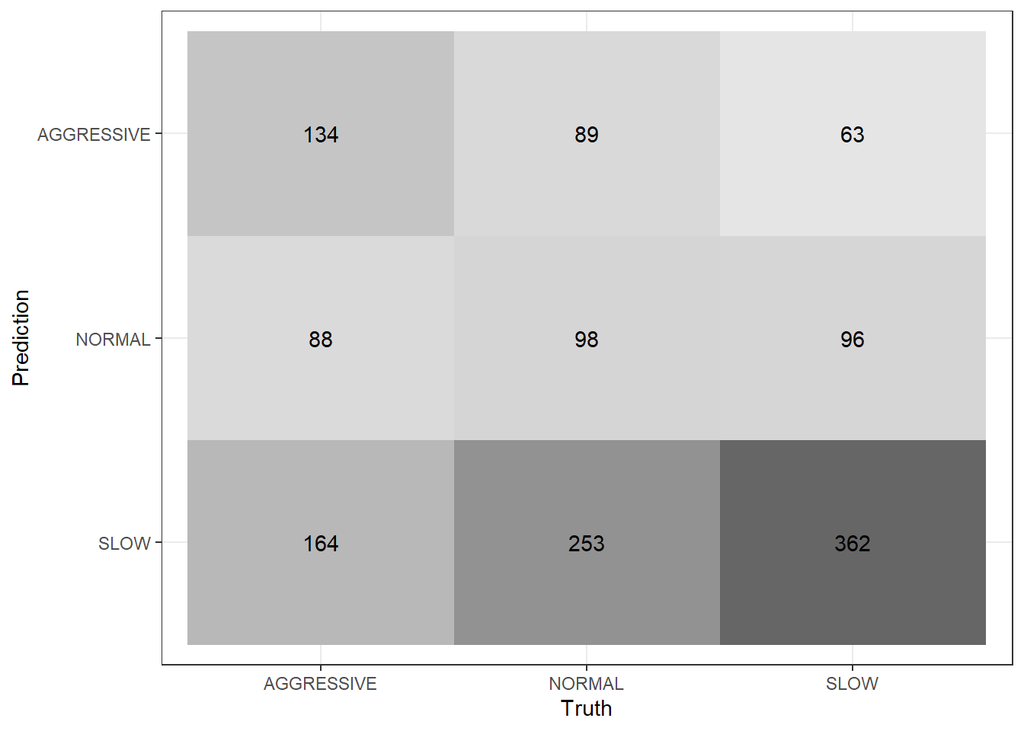

```r
conf_mat(final_rf_model_test, truth = Class,
         .pred_class) %>%
  autoplot(type = "heatmap")
```

```r
combined_data <- read.csv('~/Github/pstat131FinalProject/data/combined_motion_data.csv')

combined_data <- combined_data %>%
  mutate(Class = factor(ifelse(Class %in% c("NORMAL", "SLOW"), "SAFE", as.character(Class))))

head(combined_data)
```

```
##      AccX    AccY     AccZ    GyroX     GyroY   GyroZ Class Timestamp
## 1  0.0000  0.0000  0.00000  0.05941 -0.174707 0.10194  SAFE   3581629
## 2 -1.6249 -1.0825 -0.20418 -0.02856  0.051313 0.13554  SAFE   3581630
## 3 -0.5947 -0.1224  0.22050 -0.01939 -0.029322 0.08789  SAFE   3581630
## 4  0.7385 -0.2285  0.66773  0.06979 -0.029932 0.05490  SAFE   3581631
## 5  0.1017  0.7776 -0.06673  0.03070 -0.003665 0.05490  SAFE   3581631
## 6  0.1585  0.3459  0.35527  0.02153  0.115454 0.01458  SAFE   3581632
```

```r
# Set a seed for reproducibility
set.seed(123)

# Define the percentage for the training set (e.g., 80%)
train_percent <- 0.8

# Create a data splitting object with stratified sampling
data_split <- initial_split(combined_data, prop = train_percent, strata = Class)

# Extract the training and testing sets
data_train <- training(data_split)
data_test <- testing(data_split)

# Check the dimensions of the training and testing sets
dim(data_train)
```

```
## [1] 5381    8
```

```r
dim(data_test)
```

```
## [1] 1347    8
```

```r
# Set seed for reproducibility
set.seed(123)

# Define the number of folds
num_folds <- 5

# Create a cross-validation object
data_folds <- vfold_cv(data_train, v = num_folds, strata = "Class")

# Display the folds
data_folds
```

```
## #  5-fold cross-validation using stratification
## # A tibble: 5 × 2
##   splits              id
##   <list>              <chr>
## 1 <split [4304/1077]> Fold1
## 2 <split [4305/1076]> Fold2
## 3 <split [4305/1076]> Fold3
## 4 <split [4305/1076]> Fold4
## 5 <split [4305/1076]> Fold5
```

```r
# Create a recipe
data_recipe <- recipe(Class ~ AccX + AccY + GyroX + GyroY + GyroZ, data = data_train) %>%

  # Center and scale all predictors
  step_normalize(all_predictors())
```

```r
# Specify logistic regression model
logistic_model <- logistic_reg(mode = "classification", engine = "glm")

# Create a workflow
lm_data_workflow <- workflow() %>%
  add_model(logistic_model) %>%
  add_recipe(data_recipe)

lm_fit_val_data <- lm_data_workflow %>%
  fit_resamples(resamples = data_folds)

collect_metrics(lm_fit_val_data)
```

```
## # A tibble: 2 × 6
##   .metric  .estimator  mean     n  std_err .config
##   <chr>    <chr>      <dbl> <int>    <dbl> <chr>
## 1 accuracy binary     0.718     5 0.000487 Preprocessor1_Model1
## 2 roc_auc  binary     0.568     5 0.00584  Preprocessor1_Model1
```

```r
# Create a KNN model with k = 5 using the kknn engine
knn_model <- nearest_neighbor(neighbors = tune()) %>%
  set_mode("classification") %>%
  set_engine("kknn")

knn_data_workflow <- workflow() %>%
  add_recipe(data_recipe) %>%
  add_model(knn_model)

neighbors_grid <- grid_regular(neighbors(range = c(1, 10)), levels = 10)

# Specify logistic regression model
logistic_model <- logistic_reg(mode = "classification", engine = "glm")

# Create a workflow
lm_titanic_workflow <- workflow() %>%
  add_model(logistic_model) %>%
  add_recipe(data_recipe)

# Elastic Net
data_en_spec <- logistic_reg(mixture = tune(),
                      penalty = tune()) %>%
  set_mode("classification") %>%
  set_engine("glmnet")

data_en_workflow <- workflow() %>%
  add_recipe(data_recipe) %>%
  add_model(data_en_spec)

data_en_grid <- grid_regular(penalty(range = c(0, 1)),
                        mixture(range = c(0, 1)),
                             levels = 10)
```

```r
knn_tune_res_data <- tune_grid(
  object = knn_data_workflow,
  resamples = data_folds,
  grid = neighbors_grid
)

lm_fit_val_data <- lm_data_workflow %>%
  fit_resamples(resamples = data_folds)

en_tune_res_data<- tune_grid(
  data_en_workflow,
  resamples = data_folds,
  grid = data_en_grid
)
```

#### Question 11

Use `collect_metrics()` to print the mean and standard errors of the performance metric *area under the ROC curve* for each model across folds.

```r
collect_metrics(knn_tune_res_data)
```

```
## # A tibble: 20 × 7
##    neighbors .metric  .estimator  mean     n std_err .config
##        <int> <chr>    <chr>      <dbl> <int>   <dbl> <chr>
##  1         1 accuracy binary     0.628     5 0.00782 Preprocessor1_Model01
##  2         1 roc_auc  binary     0.541     5 0.00553 Preprocessor1_Model01
##  3         2 accuracy binary     0.628     5 0.00782 Preprocessor1_Model02
##  4         2 roc_auc  binary     0.559     5 0.00443 Preprocessor1_Model02
##  5         3 accuracy binary     0.628     5 0.00782 Preprocessor1_Model03
##  6         3 roc_auc  binary     0.573     5 0.00230 Preprocessor1_Model03
##  7         4 accuracy binary     0.628     5 0.00782 Preprocessor1_Model04
##  8         4 roc_auc  binary     0.577     5 0.00375 Preprocessor1_Model04
##  9         5 accuracy binary     0.673     5 0.00375 Preprocessor1_Model05
## 10         5 roc_auc  binary     0.584     5 0.00283 Preprocessor1_Model05
## 11         6 accuracy binary     0.681     5 0.00363 Preprocessor1_Model06
## 12         6 roc_auc  binary     0.589     5 0.00396 Preprocessor1_Model06
## 13         7 accuracy binary     0.681     5 0.00363 Preprocessor1_Model07
## 14         7 roc_auc  binary     0.593     5 0.00371 Preprocessor1_Model07
## 15         8 accuracy binary     0.690     5 0.00374 Preprocessor1_Model08
## 16         8 roc_auc  binary     0.596     5 0.00409 Preprocessor1_Model08
## 17         9 accuracy binary     0.701     5 0.00441 Preprocessor1_Model09
## 18         9 roc_auc  binary     0.599     5 0.00414 Preprocessor1_Model09
## 19        10 accuracy binary     0.704     5 0.00523 Preprocessor1_Model10
## 20        10 roc_auc  binary     0.602     5 0.00445 Preprocessor1_Model10
```

```r
collect_metrics(lm_fit_val_data)
```

```
## # A tibble: 2 × 6
##   .metric  .estimator  mean     n  std_err .config
##   <chr>    <chr>      <dbl> <int>    <dbl> <chr>
## 1 accuracy binary     0.718     5 0.000487 Preprocessor1_Model1
## 2 roc_auc  binary     0.568     5 0.00584  Preprocessor1_Model1
```

```r
collect_metrics(en_tune_res_data)
```

```
## # A tibble: 200 × 8
##    penalty mixture .metric  .estimator  mean     n  std_err .config
##      <dbl>   <dbl> <chr>    <chr>      <dbl> <int>    <dbl> <chr>
##  1    1          0 accuracy binary     0.714     5 0.000133 Preprocessor1_Model…
##  2    1          0 roc_auc  binary     0.565     5 0.00716  Preprocessor1_Model…
##  3    1.29       0 accuracy binary     0.714     5 0.000133 Preprocessor1_Model…
##  4    1.29       0 roc_auc  binary     0.564     5 0.00722  Preprocessor1_Model…
##  5    1.67       0 accuracy binary     0.714     5 0.000133 Preprocessor1_Model…
##  6    1.67       0 roc_auc  binary     0.564     5 0.00726  Preprocessor1_Model…
##  7    2.15       0 accuracy binary     0.714     5 0.000133 Preprocessor1_Model…
##  8    2.15       0 roc_auc  binary     0.564     5 0.00732  Preprocessor1_Model…
##  9    2.78       0 accuracy binary     0.714     5 0.000133 Preprocessor1_Model…
## 10    2.78       0 roc_auc  binary     0.564     5 0.00735  Preprocessor1_Model…
## # ℹ 190 more rows
```

```r
# Load Necessary Libraries & Source Custom Functions
library(tidyverse)
library(tidymodels)
library(tidytext)
library(keras)
library(tensorflow)
# source('~/GitHub/module2-f23-module2-group9/scripts/preprocessing.R')
```

```r
# Split the data into training and test sets
set.seed(102722)
partitions <- combined_data %>%
  initial_split(prop = 0.8)
```

```r
# Must run this code prior using Tensorflow
use_virtualenv("r-reticulate")
```

```r
head(combined_data)
```

```
##      AccX    AccY     AccZ    GyroX     GyroY   GyroZ Class Timestamp
## 1  0.0000  0.0000  0.00000  0.05941 -0.174707 0.10194  SAFE   3581629
## 2 -1.6249 -1.0825 -0.20418 -0.02856  0.051313 0.13554  SAFE   3581630
## 3 -0.5947 -0.1224  0.22050 -0.01939 -0.029322 0.08789  SAFE   3581630
## 4  0.7385 -0.2285  0.66773  0.06979 -0.029932 0.05490  SAFE   3581631
## 5  0.1017  0.7776 -0.06673  0.03070 -0.003665 0.05490  SAFE   3581631
## 6  0.1585  0.3459  0.35527  0.02153  0.115454 0.01458  SAFE   3581632
```

```r
# Load Necessary Libraries & Source Custom Functions
library(tidyverse)
library(tidymodels)
library(tidytext)
library(keras)
library(tensorflow)

# Split the data into training and test sets
set.seed(102722)
partitions <- combined_data %>%
  initial_split(prop = 0.8)

# Extract features for multiclass classification
x_train_multiclass <- training(partitions) %>%
  select(AccX, AccY, AccZ, GyroX, GyroY, GyroZ) %>%
  as.matrix()

# Reshape input data for LSTM (assuming 3 time steps for each feature)
time_steps <- 2
features <- ncol(x_train_multiclass)
x_train_multiclass <- array(x_train_multiclass, dim = c(nrow(x_train_multiclass), time_steps, features))

# Extract multiclass labels
y_train_multiclass <- training(partitions) %>%
  pull(Class) %>%
  as.numeric() - 1

y_train_multiclass <- to_categorical(y_train_multiclass, num_classes = 2)

# Specify and compile LSTM model
model_multiclass_lstm <- keras_model_sequential() %>%
  layer_lstm(units = 50, input_shape = c(time_steps, features)) %>%
  layer_dropout(rate = 0.5) %>%
  layer_dense(units = 2, activation = 'softmax')

model_multiclass_lstm %>%
  compile(
    loss = 'categorical_crossentropy',
    optimizer = optimizer_adam(lr = 0.001),
    metrics = c('accuracy')
  )

# Train the LSTM model
history_multiclass_lstm <- model_multiclass_lstm %>%
  fit(
    x = x_train_multiclass,
    y = y_train_multiclass,
    validation_split = 0.2,
    epochs = 10,
    batch_size = 32
  )
```

```
## 135/135 - 2s - loss: 0.6287 - accuracy: 0.6976 - val_loss: 0.5740 - val_accuracy: 0.7289 - 2s/epoch - 14ms/step
## 135/135 - 0s - loss: 0.5789 - accuracy: 0.7226 - val_loss: 0.5546 - val_accuracy: 0.7502 - 234ms/epoch - 2ms/step
## 135/135 - 0s - loss: 0.5712 - accuracy: 0.7292 - val_loss: 0.5510 - val_accuracy: 0.7530 - 235ms/epoch - 2ms/step
## 135/135 - 0s - loss: 0.5638 - accuracy: 0.7308 - val_loss: 0.5500 - val_accuracy: 0.7577 - 227ms/epoch - 2ms/step
## 135/135 - 0s - loss: 0.5651 - accuracy: 0.7310 - val_loss: 0.5502 - val_accuracy: 0.7539 - 215ms/epoch - 2ms/step
## 135/135 - 0s - loss: 0.5644 - accuracy: 0.7329 - val_loss: 0.5479 - val_accuracy: 0.7595 - 229ms/epoch - 2ms/step
## 135/135 - 0s - loss: 0.5605 - accuracy: 0.7326 - val_loss: 0.5478 - val_accuracy: 0.7521 - 224ms/epoch - 2ms/step
## 135/135 - 0s - loss: 0.5619 - accuracy: 0.7345 - val_loss: 0.5466 - val_accuracy: 0.7586 - 219ms/epoch - 2ms/step
## 135/135 - 0s - loss: 0.5601 - accuracy: 0.7370 - val_loss: 0.5474 - val_accuracy: 0.7558 - 241ms/epoch - 2ms/step
## 135/135 - 0s - loss: 0.5590 - accuracy: 0.7384 - val_loss: 0.5461 - val_accuracy: 0.7558 - 251ms/epoch - 2ms/step
```

```r
library(pROC)
library(caret)

y_test_multiclass <- testing(partitions) %>%
  pull(Class) %>%
  as.numeric() - 1

# Extract features for multiclass classification
x_test_multiclass <- testing(partitions) %>%
  select(AccX, AccY, AccZ, GyroX, GyroY, GyroZ) %>%
  as.matrix()

# Assuming time_steps is 2 and features is the number of features
time_steps <- 2
features <- ncol(x_test_multiclass)

# Reshape input data for LSTM
x_test_multiclass <- array(x_test_multiclass, dim = c(nrow(x_test_multiclass), time_steps, features))

y_test_multiclass <- to_categorical(y_test_multiclass, num_classes = 2)


# Evaluate the best model on the test set
test_metrics <- model_multiclass_lstm %>% evaluate(x_test_multiclass, y_test_multiclass)
```

```
## 43/43 - 0s - loss: 0.5560 - accuracy: 0.7370 - 48ms/epoch - 1ms/step
```

```r
# Print test metrics
print(test_metrics)
```

```
##     loss accuracy
##    0.556    0.737
```

```r
# Predictions on the test set
probabilities <- model_multiclass_lstm %>% predict(x_test_multiclass)
```

```
## 43/43 - 0s - 322ms/epoch - 7ms/step
```

```r
predictions <- max.col(probabilities) - 1

# Convert predictions and true labels to factor
predictions_factor <- factor(predictions, levels = 0:1, labels = c("AGGRESSIVE", "SAFE"))
y_test_multiclass_factor <- factor(y_test_multiclass, levels = 0:1, labels = c("AGGRESSIVE", "SAFE"))

# ROC Curve
# roc_results <- roc(y_test_multiclass_factor, as.numeric(predictions_factor))
# plot(roc_results, col = c("blue", "red"), lty = c(1, 1), lwd = 2)
#
# # Confusion Matrix
# conf_mat <- confusionMatrix(predictions_factor, y_test_multiclass_factor)
# print(conf_mat)
#
# # Confusion Matrix Plot
# confusionMatrix::confusionMatrix(predictions_factor, y_test_multiclass_factor) %>%
#   autoplot(type = "heatmap")
```

```r
# best_lstm <- model_multiclass_lstm
#
# final_lstm_model_test <- augment(best_lstm,
#                                data_test) %>%
#   select(Class, starts_with(".pred"))
#
# roc_results_lstm <- roc_auc(final_lstm_model_test, truth = Class, .pred_AGGRESSIVE:.pred_SAFE)
#
#
# roc_curve(final_lstm_model_test, truth = Class, .pred_AGGRESSIVE:.pred_SAFE) %>%
#   autoplot()
#
#
# conf_mat(final_lstm_model_test, truth = Class,
#          .pred_class) %>%
#   autoplot(type = "heatmap")
#
# roc_results_lstm
```

```r
# Evaluate Multiclass LSTM Model using the training/testing partition (not the testing data)
evaluate(model_multiclass_lstm, x_train_multiclass, y_train_multiclass)
```

```
## 169/169 - 0s - loss: 0.5518 - accuracy: 0.7421 - 141ms/epoch - 835us/step
```

```
##     loss accuracy
##   0.5518   0.7421
```

```r
# Load Necessary Libraries & Source Custom Functions
library(tidyverse)
library(tidymodels)
library(tidytext)
library(keras)
library(tensorflow)
library(dplyr)

# Assuming your response variable is a factor
combined_data <- combined_data %>%
  mutate(Class = factor(ifelse(Class %in% c("NORMAL", "SLOW"), "SAFE", as.character(Class))))


# Split the data into training and test sets
set.seed(102722)
partitions <- combined_data %>%
  initial_split(prop = 0.8)

# Extract features for multiclass classification
x_train_multiclass <- training(partitions) %>%
  select(AccX, AccY, AccZ, GyroX, GyroY, GyroZ) %>%
  as.matrix()

# Reshape input data for LSTM (assuming 3 time steps for each feature)
time_steps <- 3
n_features <- ncol(x_train_multiclass)
x_train_multiclass <- array(x_train_multiclass, dim = c(nrow(x_train_multiclass), time_steps, features))

# Extract multiclass labels
y_train_multiclass <- training(partitions) %>%
  pull(Class) %>%
  as.numeric() - 1

y_train_multiclass <- to_categorical(y_train_multiclass, num_classes = 3)

# Make sure to adjust input shapes, units, and other parameters based on your data
model_cnn_lstm_2classes <- keras_model_sequential() %>%
  layer_conv_1d(filters = 32, kernel_size = 2, activation = 'relu', input_shape = c(time_steps, n_features)) %>%
  layer_lstm(units = 50, activation = 'relu') %>%
  layer_dropout(0.5) %>%
  layer_dense(units = 3, activation = 'softmax')  # Assuming 2 classes

model_cnn_lstm_2classes %>%
  compile(
    loss = 'categorical_crossentropy',
    optimizer = optimizer_adam(lr = 0.001),
    metrics = c('accuracy')
  )

# Train the CNN-LSTM model with your data
# Make sure to adjust x_train, y_train, validation_split, epochs, and batch_size
history_cnn_lstm_2classes <- model_cnn_lstm_2classes %>%
  fit(
    x = x_train_multiclass,
    y = y_train_multiclass,
    validation_split = 0.2,
    epochs = 10,
    batch_size = 32
  )
```

```
## 135/135 - 1s - loss: 0.8193 - accuracy: 0.6952 - val_loss: 0.5856 - val_accuracy: 0.7382 - 1s/epoch - 11ms/step
## 135/135 - 0s - loss: 0.6116 - accuracy: 0.7220 - val_loss: 0.5582 - val_accuracy: 0.7558 - 217ms/epoch - 2ms/step
## 135/135 - 0s - loss: 0.5830 - accuracy: 0.7298 - val_loss: 0.5488 - val_accuracy: 0.7539 - 233ms/epoch - 2ms/step
## 135/135 - 0s - loss: 0.5730 - accuracy: 0.7319 - val_loss: 0.5474 - val_accuracy: 0.7530 - 218ms/epoch - 2ms/step
## 135/135 - 0s - loss: 0.5690 - accuracy: 0.7329 - val_loss: 0.5465 - val_accuracy: 0.7539 - 214ms/epoch - 2ms/step
## 135/135 - 0s - loss: 0.5704 - accuracy: 0.7338 - val_loss: 0.5474 - val_accuracy: 0.7595 - 226ms/epoch - 2ms/step
## 135/135 - 0s - loss: 0.5630 - accuracy: 0.7387 - val_loss: 0.5483 - val_accuracy: 0.7558 - 219ms/epoch - 2ms/step
## 135/135 - 0s - loss: 0.5685 - accuracy: 0.7285 - val_loss: 0.5484 - val_accuracy: 0.7558 - 225ms/epoch - 2ms/step
## 135/135 - 0s - loss: 0.5629 - accuracy: 0.7375 - val_loss: 0.5526 - val_accuracy: 0.7632 - 240ms/epoch - 2ms/step
## 135/135 - 0s - loss: 0.5592 - accuracy: 0.7347 - val_loss: 0.5520 - val_accuracy: 0.7512 - 242ms/epoch - 2ms/step
```

```r
# Evaluate CNN-LSTM Model using the training/testing partition (not the testing data)
evaluate(model_cnn_lstm_2classes, x_train_multiclass, y_train_multiclass)
```

```
## 169/169 - 0s - loss: 0.5539 - accuracy: 0.7389 - 126ms/epoch - 747us/step
```

```
##     loss accuracy
##   0.5539   0.7389
```

```r
# Get Multiclass Model Details
summary(model_multiclass_lstm)
```

```
## Model: "sequential"
## ________________________________________________________________________________
##  Layer (type)                       Output Shape                    Param #
## ================================================================================
##  lstm (LSTM)                        (None, 50)                      11400
##  dropout (Dropout)                  (None, 50)                      0
##  dense (Dense)                      (None, 2)                       102
## ================================================================================
## Total params: 11502 (44.93 KB)
## Trainable params: 11502 (44.93 KB)
## Non-trainable params: 0 (0.00 Byte)
## ________________________________________________________________________________
```

```r
# # Make predictions on the test data
# preds_multiclass <- predict(model_multiclass_lstm, y_test_multiclass) %>%
#   as.data.frame()
#
# # Assuming preds_multiclass is a matrix of predicted probabilities
# #pred_classes_multiclass <- max.col(preds_multiclass)
#
# # Assuming preds_multiclass is a data frame of predicted probabilities with one row for each observation and one column for each class
#
# # Get the predicted classes (column name with the highest probability for each observation)
# pred_classes_multiclass <- colnames(preds_multiclass)[apply(preds_multiclass, 1, which.max)]
#
# # Format multiclass predictions
# class_labels_multiclass <- combined_data %>% pull(Class) %>% levels()
# pred_classes_multiclass <- factor(pred_classes_multiclass, levels = class_labels_multiclass)
#
# # Create multiclass prediction data frame
# pred_df_multiclass <- data_test %>%
#   bind_cols(mclass.pred = pred_classes_multiclass) %>%
#   select(Class.pred)
#
#
# # Save the multiclass prediction data frame
# #save(pred_df_multiclass, file = "~/GitHub/module2-f23-module2-group9/results/Ryan_Multiclass_Model_Prediction.RData")
#
# #save_model_tf(model_binary, "~/GitHub/module2-f23-module2-group9/results")
```